# K-means clustering

Harika

11/1/2019

Libraries may useful in this k-means clustering

```r
library(tidyr)
library(tidyselect)
library(factoextra)
library(magrittr)
library(caret)
library(VIM)
library(dplyr)
library(magrittr)
library(imputeTS)
library(stats)
library(flexclust)
```

Given information The dataset on American College and University Rankings contains information on 1302 American colleges and universities offering an undergraduate program. For each university, there are 17 measurements, including continuous measurements (such as tuition and grad- uation rate) and categorical measurements (such as location by state and whether it is a private or public school).

Question1:Remove all records with missing measurements from the dataset.

```r
#read data
Mydata <- read.csv("Universities.csv")
str(Mydata)
```

```
## 'data.frame':    1302 obs. of  20 variables:
##  $ College.Name             : Factor w/ 1274 levels "Abilene Christian University",..: 8 1004 1005 1003 6 327 1084 7 43 88 ...
##  $ State                    : Factor w/ 51 levels "AK","AL","AR",..: 1 1 1 1 2 2 2 2 2 2 ...
##  $ Public..1...Private..2.  : int  2 1 1 1 1 2 1 1 1 2 ...
##  $ X..appli..rec.d          : int  193 1852 146 2065 2817 345 1351 4639 7548 805 ...
##  $ X..appl..accepted        : int  146 1427 117 1598 1920 320 892 3272 6791 588 ...
##  $ X..new.stud..enrolled    : int  55 928 89 1162 984 179 570 1278 3070 287 ...
##  $ X..new.stud..from.top.10.: int  16 NA 4 NA NA NA 18 NA 25 67 ...
##  $ X..new.stud..from.top.25.: int  44 NA 24 NA NA 27 78 NA 57 88 ...
##  $ X..FT.undergrad          : int  249 3885 492 6209 3958 1367 2385 4051 16262 1376 ...
##  $ X..PT.undergrad          : int  869 4519 1849 10537 305 578 331 405 1716 207 ...
##  $ in.state.tuition         : int  7560 1742 1742 1742 1700 5600 2220 1500 2100 11660 ...
##  $ out.of.state.tuition     : int  7560 5226 5226 5226 3400 5600 4440 3000 6300 11660 ...
##  $ room                     : int  1620 1800 2514 2600 1108 1550 NA 1960 NA 2050 ...
##  $ board                    : int  2500 1790 2250 2520 1442 1700 NA NA NA 2430 ...
##  $ add..fees                : int  130 155 34 114 155 300 124 84 NA 120 ...
##  $ estim..book.costs        : int  800 650 500 580 500 350 300 500 600 400 ...
##  $ estim..personal..        : int  1500 2304 1162 1260 850 NA 600 NA 1908 900 ...
##  $ X..fac..w.PHD            : int  76 67 39 48 53 52 72 48 85 74 ...
##  $ stud..fac..ratio         : num  11.9 10 9.5 13.7 14.3 32.8 18.9 18.7 16.7 14 ...
##  $ Graduation.rate          : int  15 NA 39 NA 40 55 51 15 69 72 ...
```

```r
#removing missing measurements from dataset
Mydata_all <- na.omit(Mydata)

#Having only continuous variables
Mydata1 <- Mydata_all[-c(1, 2, 3) ]
str(Mydata1)
```

```
## 'data.frame':    471 obs. of  17 variables:
##  $ X..appli..rec.d          : int  193 146 805 608 4414 1797 708 823 605 1721 ...
##  $ X..appl..accepted        : int  146 117 588 520 1500 1260 334 721 405 1068 ...
##  $ X..new.stud..enrolled    : int  55 89 287 127 335 938 166 274 284 806 ...
##  $ X..new.stud..from.top.10.: int  16 4 67 26 30 24 46 52 24 35 ...
##  $ X..new.stud..from.top.25.: int  44 24 88 47 60 35 74 87 53 75 ...
##  $ X..FT.undergrad          : int  249 492 1376 538 908 6960 530 954 961 3128 ...
##  $ X..PT.undergrad          : int  869 1849 207 126 119 4698 182 6 99 213 ...
##  $ in.state.tuition         : int  7560 1742 11660 8080 5666 2220 8644 8800 6398 5504 ...
##  $ out.of.state.tuition     : int  7560 5226 11660 8080 5666 4440 8644 8800 6398 5504 ...
##  $ room                     : int  1620 2514 2050 1380 1424 1935 2382 1935 1450 1650 ...
##  $ board                    : int  2500 2250 2430 2540 1540 3240 1540 1260 2222 1878 ...
##  $ add..fees                : int  130 34 120 100 418 291 120 325 148 1016 ...
##  $ estim..book.costs        : int  800 500 400 500 1000 750 500 500 400 700 ...
##  $ estim..personal..        : int  1500 1162 900 1100 1400 2200 800 1200 1350 910 ...
##  $ X..fac..w.PHD            : int  76 39 74 63 56 96 79 82 68 71 ...
##  $ stud..fac..ratio         : num  11.9 9.5 14 11.4 15.5 6.7 12.6 13.1 13.3 17.7 ...
##  $ Graduation.rate          : int  15 39 72 44 46 33 54 63 75 73 ...
```

```r
summary(Mydata1)
```

```
##  X..appli..rec.d X..appl..accepted X..new.stud..enrolled
##  Min.   :   77   Min.   :   61.0   Min.   :  27.0
##  1st Qu.:  802   1st Qu.:  635.5   1st Qu.: 264.0
##  Median : 1646   Median : 1227.0   Median : 443.0
##  Mean   : 3147   Mean   : 2063.0   Mean   : 780.7
##  3rd Qu.: 3862   3rd Qu.: 2456.0   3rd Qu.: 896.5
##  Max.   :48094   Max.   :26330.0   Max.   :6392.0
##  X..new.stud..from.top.10. X..new.stud..from.top.25. X..FT.undergrad
##  Min.   : 1.00             Min.   :  9.00            Min.   :  249
##  1st Qu.:15.00             1st Qu.: 40.00            1st Qu.: 1018
##  Median :23.00             Median : 54.00            Median : 1715
##  Mean   :28.01             Mean   : 55.65            Mean   : 3563
##  3rd Qu.:36.00             3rd Qu.: 69.00            3rd Qu.: 4056
##  Max.   :96.00             Max.   :100.00            Max.   :31643
##  X..PT.undergrad   in.state.tuition out.of.state.tuition      room
##  Min.   :    1.0   Min.   :  608    Min.   : 1044        Min.   : 640
##  1st Qu.:   81.5   1st Qu.: 3650    1st Qu.: 7290        1st Qu.:1740
##  Median :  299.0   Median : 9858    Median :10100        Median :2090
##  Mean   :  797.5   Mean   : 9407    Mean   :10575        Mean   :2221
##  3rd Qu.:  869.0   3rd Qu.:13246    3rd Qu.:13286        3rd Qu.:2663
##  Max.   :21836.0   Max.   :20100    Max.   :20100        Max.   :4816
##      board        add..fees      estim..book.costs estim..personal..
##  Min.   : 531   Min.   :  10.0   Min.   :  90.0    Min.   : 250
##  1st Qu.:1750   1st Qu.: 137.5   1st Qu.: 500.0    1st Qu.: 850
##  Median :2082   Median : 280.0   Median : 500.0    Median :1200
##  Mean   :2122   Mean   : 379.0   Mean   : 548.8    Mean   :1312
##  3rd Qu.:2420   3rd Qu.: 486.0   3rd Qu.: 600.0    3rd Qu.:1600
##  Max.   :4541   Max.   :3247.0   Max.   :2340.0    Max.   :6800
##  X..fac..w.PHD    stud..fac..ratio Graduation.rate
##  Min.   :  8.00   Min.   : 2.90    Min.   : 15.00
##  1st Qu.: 63.00   1st Qu.:11.30    1st Qu.: 53.00
##  Median : 76.00   Median :13.40    Median : 66.00
##  Mean   : 73.21   Mean   :13.96    Mean   : 65.56
##  3rd Qu.: 87.00   3rd Qu.:16.45    3rd Qu.: 79.00
##  Max.   :103.00   Max.   :28.80    Max.   :118.00
```

```r
summary(Mydata_all)
```

```
##                    College.Name     State     Public..1...Private..2.
##  Trinity College         :  4   PA     : 42   Min.   :1.000
##  Augustana College       :  2   NY     : 38   1st Qu.:1.000
##  Monmouth College        :  2   OH     : 24   Median :2.000
##  University of St. Thomas:  2   NC     : 23   Mean   :1.728
##  Westminster College     :  2   MA     : 22   3rd Qu.:2.000
##  Adams State College     :  1   TX     : 20   Max.   :2.000
##  (Other)                 :458   (Other):302
##  X..appli..rec.d X..appl..accepted X..new.stud..enrolled
##  Min.   :   77   Min.   :   61.0   Min.   :  27.0
##  1st Qu.:  802   1st Qu.:  635.5   1st Qu.: 264.0
##  Median : 1646   Median : 1227.0   Median : 443.0
##  Mean   : 3147   Mean   : 2063.0   Mean   : 780.7
##  3rd Qu.: 3862   3rd Qu.: 2456.0   3rd Qu.: 896.5
##  Max.   :48094   Max.   :26330.0   Max.   :6392.0
##
##  X..new.stud..from.top.10. X..new.stud..from.top.25. X..FT.undergrad
##  Min.   : 1.00             Min.   :  9.00            Min.   :  249
##  1st Qu.:15.00             1st Qu.: 40.00            1st Qu.: 1018
##  Median :23.00             Median : 54.00            Median : 1715
##  Mean   :28.01             Mean   : 55.65            Mean   : 3563
##  3rd Qu.:36.00             3rd Qu.: 69.00            3rd Qu.: 4056
##  Max.   :96.00             Max.   :100.00            Max.   :31643
##
##  X..PT.undergrad   in.state.tuition out.of.state.tuition      room
##  Min.   :    1.0   Min.   :  608    Min.   : 1044        Min.   : 640
##  1st Qu.:   81.5   1st Qu.: 3650    1st Qu.: 7290        1st Qu.:1740
##  Median :  299.0   Median : 9858    Median :10100        Median :2090
##  Mean   :  797.5   Mean   : 9407    Mean   :10575        Mean   :2221
##  3rd Qu.:  869.0   3rd Qu.:13246    3rd Qu.:13286        3rd Qu.:2663
##  Max.   :21836.0   Max.   :20100    Max.   :20100        Max.   :4816
##
##      board        add..fees      estim..book.costs estim..personal..
##  Min.   : 531   Min.   :  10.0   Min.   :  90.0    Min.   : 250
##  1st Qu.:1750   1st Qu.: 137.5   1st Qu.: 500.0    1st Qu.: 850
##  Median :2082   Median : 280.0   Median : 500.0    Median :1200
##  Mean   :2122   Mean   : 379.0   Mean   : 548.8    Mean   :1312
##  3rd Qu.:2420   3rd Qu.: 486.0   3rd Qu.: 600.0    3rd Qu.:1600
##  Max.   :4541   Max.   :3247.0   Max.   :2340.0    Max.   :6800
##
##  X..fac..w.PHD    stud..fac..ratio Graduation.rate
##  Min.   :  8.00   Min.   : 2.90    Min.   : 15.00
##  1st Qu.: 63.00   1st Qu.:11.30    1st Qu.: 53.00
##  Median : 76.00   Median :13.40    Median : 66.00
##  Mean   : 73.21   Mean   :13.96    Mean   : 65.56
##  3rd Qu.: 87.00   3rd Qu.:16.45    3rd Qu.: 79.00
##  Max.   :103.00   Max.   :28.80    Max.   :118.00
##
```

2. For all the continuous measurements, run K-Means clustering. Make sure to normalize the measurements. How many clusters seem reasonable for describing these data? What was your optimal K?

```r
#Data normalization(preprocessing)
set.seed(123)
Mydata1_norm <- preProcess(Mydata1, method=c("center", "scale"))
Mydata1_norm <- predict(Mydata1_norm,Mydata1)
summary(Mydata1_norm)
```

```
##  X..appli..rec.d   X..appl..accepted X..new.stud..enrolled
##  Min.   :-0.7538   Min.   :-0.7996   Min.   :-0.8232
##  1st Qu.:-0.5758   1st Qu.:-0.5701   1st Qu.:-0.5643
##  Median :-0.3686   Median :-0.3339   Median :-0.3688
##  Mean   : 0.0000   Mean   : 0.0000   Mean   : 0.0000
##  3rd Qu.: 0.1755   3rd Qu.: 0.1570   3rd Qu.: 0.1265
##  Max.   :11.0349   Max.   : 9.6923   Max.   : 6.1283
##  X..new.stud..from.top.10. X..new.stud..from.top.25. X..FT.undergrad
##  Min.   :-1.4618           Min.   :-2.29537          Min.   :-0.7097
##  1st Qu.:-0.7042           1st Qu.:-0.77010          1st Qu.:-0.5450
##  Median :-0.2713           Median :-0.08127          Median :-0.3958
##  Mean   : 0.0000           Mean   : 0.00000          Mean   : 0.0000
##  3rd Qu.: 0.4322           3rd Qu.: 0.65676          3rd Qu.: 0.1055
##  Max.   : 3.6791           Max.   : 2.18202          Max.   : 6.0139
##  X..PT.undergrad    in.state.tuition   out.of.state.tuition
##  Min.   :-0.51524   Min.   :-1.59488   Min.   :-2.2105
##  1st Qu.:-0.46316   1st Qu.:-1.04338   1st Qu.:-0.7619
##  Median :-0.32246   Median : 0.08182   Median :-0.1102
##  Mean   : 0.00000   Mean   : 0.00000   Mean   : 0.0000
##  3rd Qu.: 0.04628   3rd Qu.: 0.69594   3rd Qu.: 0.6287
##  Max.   :13.61017   Max.   : 1.93833   Max.   : 2.2091
##       room             board            add..fees       estim..book.costs
##  Min.   :-2.2170   Min.   :-2.80658   Min.   :-1.0370   Min.   :-2.8114
##  1st Qu.:-0.6746   1st Qu.:-0.65614   1st Qu.:-0.6787   1st Qu.:-0.2989
##  Median :-0.1838   Median :-0.07046   Median :-0.2783   Median :-0.2989
##  Mean   : 0.0000   Mean   : 0.00000   Mean   : 0.0000   Mean   : 0.0000
##  3rd Qu.: 0.6196   3rd Qu.: 0.52581   3rd Qu.: 0.3006   3rd Qu.: 0.3139
##  Max.   : 3.6384   Max.   : 4.26746   Max.   : 8.0594   Max.   :10.9766
##  estim..personal.. X..fac..w.PHD     stud..fac..ratio  Graduation.rate
##  Min.   :-1.5574   Min.   :-3.9127   Min.   :-2.8374   Min.   :-2.7863
##  1st Qu.:-0.6775   1st Qu.:-0.6125   1st Qu.:-0.6829   1st Qu.:-0.6923
##  Median :-0.1642   Median : 0.1675   Median :-0.1443   Median : 0.0241
##  Mean   : 0.0000   Mean   : 0.0000   Mean   : 0.0000   Mean   : 0.0000
##  3rd Qu.: 0.4225   3rd Qu.: 0.8276   3rd Qu.: 0.6380   3rd Qu.: 0.7405
##  Max.   : 8.0488   Max.   : 1.7876   Max.   : 3.8056   Max.   : 2.8896
```

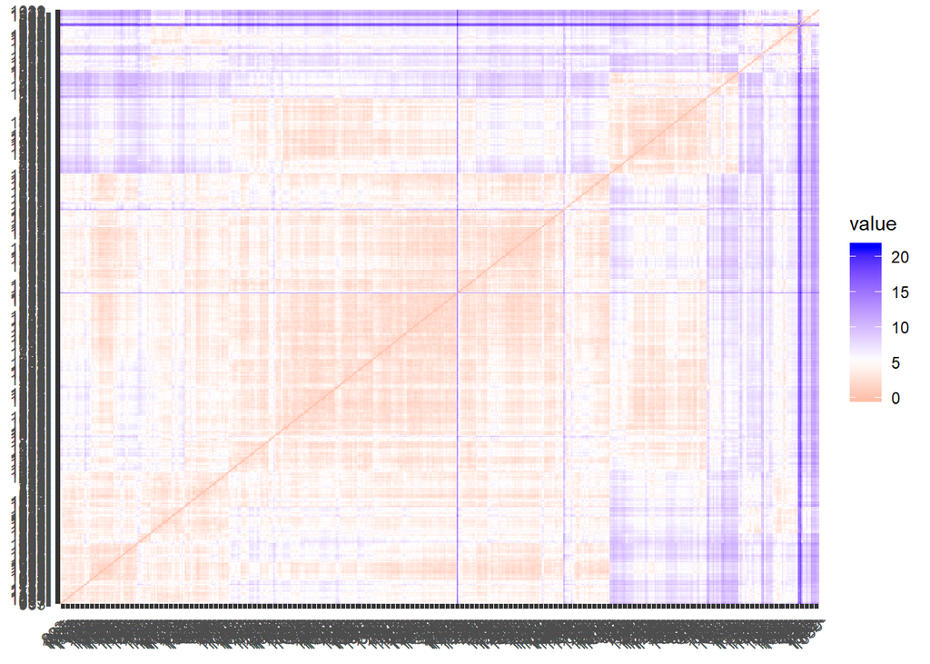

```r
#To know distance between observations
distance <- get_dist(Mydata1_norm)
fviz_dist(distance)
```

```r
#K-means clustering algorithm using k=4
k4 <- kmeans(Mydata1_norm, centers = 4, nstart = 25 )
k4
```

```
## K-means clustering with 4 clusters of sizes 46, 183, 175, 67
##
## Cluster means:
##   X..appli..rec.d X..appl..accepted X..new.stud..enrolled
## 1       1.9817966         2.2299227          2.444722e+00
## 2      -0.3692895        -0.3314846         -3.967692e-01
## 3      -0.3033156        -0.2989118         -2.276979e-01
## 4       0.4402622         0.1551461         -2.000371e-05
##   X..new.stud..from.top.10. X..new.stud..from.top.25. X..FT.undergrad
## 1                 0.1334215                 0.2545856       2.5228452
## 2                 0.0102519                 0.1080080      -0.4049392
## 3                -0.6785172                -0.7279285      -0.1972688
## 4                 1.6526422                 1.4315089      -0.1108205
##   X..PT.undergrad in.state.tuition out.of.state.tuition        room
## 1      1.74868491       -1.0500277           -0.4918168 -0.03883300
```

[output cut: 89 more lines]

```r
#Finding clustes size,center
k4$cluster
```

```
##    1    3   10   12   22   26   32   38   39   46   49   50   63   77   78
##    3    3    2    3    3    3    2    2    2    3    1    1    1    4    4
##   79   81   90   92   95   96   97  108  110  112  120  121  122  123  126
##    4    4    4    2    4    3    2    2    1    2    2    2    3    4    3
##  127  130  134  139  140  146  148  149  151  152  153  154  156  158  160
##    3    3    3    3    4    2    2    4    2    2    4    3    1    2    4
##  161  164  168  169  172  174  176  181  186  188  190  194  208  210  220
##    4    2    1    2    3    2    3    2    2    2    4    1    3    4    2
##  228  230  235  236  239  244  245  246  247  248  250  251  252  258  259
##    2    1    3    3    3    2    2    2    2    3    3    3    4    3    3
##  260  262  263  264  265  268  269  270  272  275  277  287  294  297  298
##    3    2    2    3    3    2    3    3    2    3    2    2    2    2    2
##  302  304  312  317  319  320  321  322  323  324  326  329  330  331  332
##    3    2    2    3    2    3    4    1    1    3    3    2    4    2    2
##  333  336  340  349  352  359  360  362  365  366  368  369  370  376  377
```

[output cut: 49 more lines]

```r
k4$centers
```

```
##   X..appli..rec.d X..appl..accepted X..new.stud..enrolled
## 1       1.9817966         2.2299227          2.444722e+00
## 2      -0.3692895        -0.3314846         -3.967692e-01
## 3      -0.3033156        -0.2989118         -2.276979e-01
## 4       0.4402622         0.1551461         -2.000371e-05
##   X..new.stud..from.top.10. X..new.stud..from.top.25. X..FT.undergrad
## 1                 0.1334215                 0.2545856       2.5228452
## 2                 0.0102519                 0.1080080      -0.4049392
## 3                -0.6785172                -0.7279285      -0.1972688
## 4                 1.6526422                 1.4315089      -0.1108205
##   X..PT.undergrad in.state.tuition out.of.state.tuition        room
## 1      1.74868491       -1.0500277           -0.4918168 -0.03883300
## 2     -0.25785122        0.4057712            0.2956208  0.08357902
## 3     -0.04353747       -0.7234450           -0.8237908 -0.53385193
## 4     -0.38259215        1.5022093            1.6819156  1.19276784
##        board   add..fees estim..book.costs estim..personal.. X..fac..w.PHD
## 1 -0.1745795  0.49531762       0.163585669         0.9385863     0.6840794
## 2  0.3292398 -0.18996619      -0.158302104        -0.2978018     0.0835866
## 3 -0.6791344  0.03928218       0.003218005         0.2531393    -0.6684106
## 4  0.9944521  0.07619136       0.311659604        -0.4921884     1.0478784
##   stud..fac..ratio Graduation.rate
## 1        0.6139980      -0.2538234
## 2       -0.1828501       0.3971948
## 3        0.4582141      -0.7769793
## 4       -1.1189523       1.1188151
```

```r
k4$size
```

```
## [1]  46 183 175  67
```

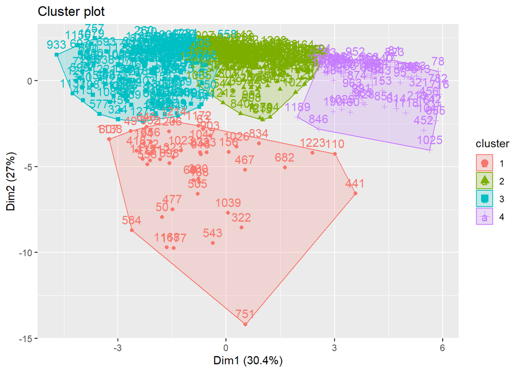

```r
#To view results of clutering
fviz_cluster(k4,data= Mydata1_norm)
```

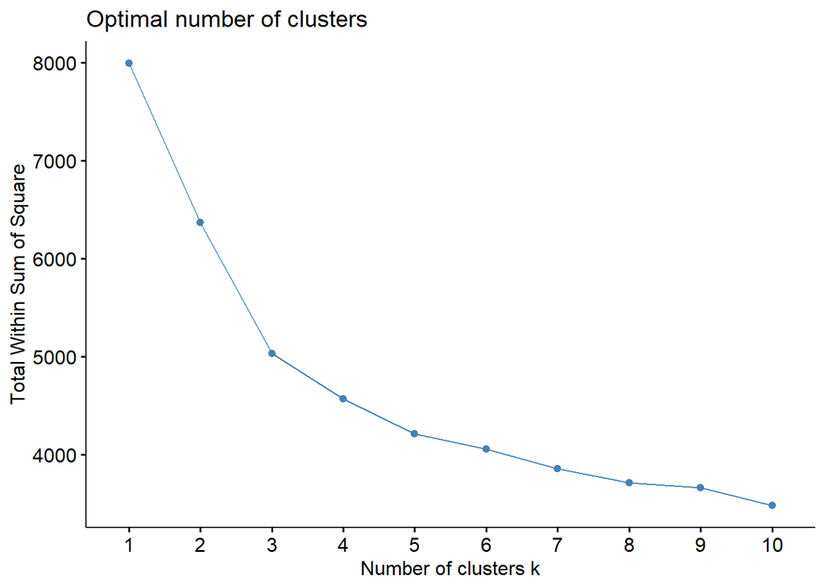

```r
#k=4 is seems to be reasonable but to find optimal k let us use WSs and silhouette method
fviz_nbclust(Mydata1_norm,kmeans,method = "wss")
```

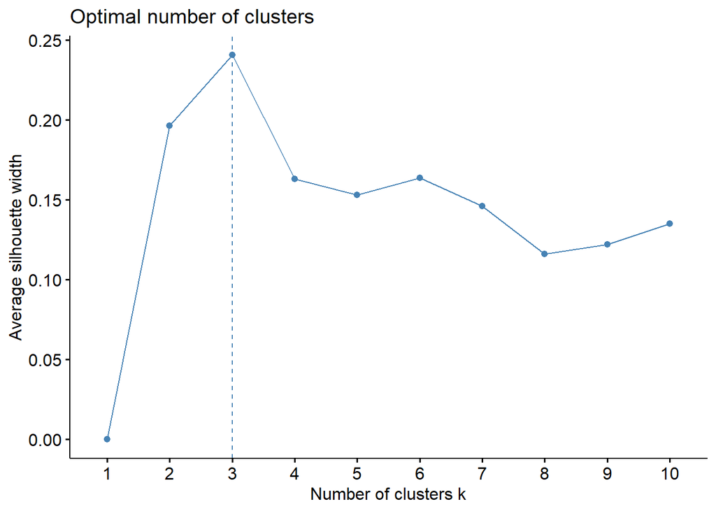

```r
fviz_nbclust(Mydata1_norm,kmeans,method = "silhouette")
```

```r
#Using ailhouette method it is clearly noticed that k=3 is optimal value
k3 <- kmeans(Mydata1_norm, centers = 3, nstart = 25 )
k3
```

```
## K-means clustering with 3 clusters of sizes 275, 150, 46
##
## Cluster means:
##   X..appli..rec.d X..appl..accepted X..new.stud..enrolled
## 1     -0.35953828       -0.34918455            -0.3171053
## 2      0.05140256       -0.04367128            -0.1683551
## 3      1.98179657        2.22992267             2.4447222
##   X..new.stud..from.top.10. X..new.stud..from.top.25. X..FT.undergrad
## 1                -0.5020886                -0.5128195      -0.2952142
## 2                 0.8795798                 0.8620961      -0.2324464
## 3                 0.1334215                 0.2545856       2.5228452
##   X..PT.undergrad in.state.tuition out.of.state.tuition       room
## 1      -0.1217682       -0.4036544           -0.5263964 -0.3588740
## 2      -0.3130216        1.0620416            1.1158839  0.6698444
## 3       1.7486849       -1.0500277           -0.4918168 -0.0388330
```

[output cut: 84 more lines]

```r
#finding cluters size and centers
k3$cluster
```

```
##    1    3   10   12   22   26   32   38   39   46   49   50   63   77   78
##    1    1    2    1    1    1    1    1    1    1    3    3    3    2    2
##   79   81   90   92   95   96   97  108  110  112  120  121  122  123  126
##    2    2    2    1    2    1    2    2    3    2    2    1    1    2    1
##  127  130  134  139  140  146  148  149  151  152  153  154  156  158  160
##    1    1    1    1    2    1    2    2    2    2    2    1    3    2    2
##  161  164  168  169  172  174  176  181  186  188  190  194  208  210  220
##    2    2    3    1    1    2    1    1    2    2    2    3    1    2    1
##  228  230  235  236  239  244  245  246  247  248  250  251  252  258  259
##    2    3    1    1    1    1    1    1    2    1    1    1    2    1    1
##  260  262  263  264  265  268  269  270  272  275  277  287  294  297  298
##    1    1    1    1    1    1    1    1    1    1    2    1    2    2    2
##  302  304  312  317  319  320  321  322  323  324  326  329  330  331  332
##    1    2    1    1    1    1    2    3    3    1    1    2    2    2    1
##  333  336  340  349  352  359  360  362  365  366  368  369  370  376  377
```

[output cut: 49 more lines]

```r
k3$centers
```

```
##   X..appli..rec.d X..appl..accepted X..new.stud..enrolled
## 1     -0.35953828       -0.34918455            -0.3171053
## 2      0.05140256       -0.04367128            -0.1683551
## 3      1.98179657        2.22992267             2.4447222
##   X..new.stud..from.top.10. X..new.stud..from.top.25. X..FT.undergrad
## 1                -0.5020886                -0.5128195      -0.2952142
## 2                 0.8795798                 0.8620961      -0.2324464
## 3                 0.1334215                 0.2545856       2.5228452
##   X..PT.undergrad in.state.tuition out.of.state.tuition       room
## 1      -0.1217682       -0.4036544           -0.5263964 -0.3588740
## 2      -0.3130216        1.0620416            1.1158839  0.6698444
## 3       1.7486849       -1.0500277           -0.4918168 -0.0388330
##        board   add..fees estim..book.costs estim..personal.. X..fac..w.PHD
## 1 -0.3938990 -0.05832646       -0.06621454        0.05935933    -0.5322257
## 2  0.7756859 -0.04496556        0.07122705       -0.39665857     0.7659627
## 3 -0.1745795  0.49531762        0.16358567        0.93858632     0.6840794
##   stud..fac..ratio Graduation.rate
## 1        0.2810858      -0.4171456
## 2       -0.7036167       0.8426062
## 3        0.6139980      -0.2538234
```

```r
k3$size
```

```
## [1] 275 150  46
```